# Statistics refresher

Linear models, interactions and mixed models

Dr Massimiliano Canzi

# From lm() to lmer()

`Did you know:` king penguins breed in colonies of up to 300,000 birds and build no nests. When a parent comes back from the sea, it and its chick find each other by call alone.

*Sources: Aubin & Jouventin (1998), Proceedings of the Royal Society B; Howlett (1998), Nature*

## Why a refresher

This course builds on Statistics. Before we add anything new, we go once through the models from that course, in the order we met them: one predictor, several predictors, interactions, and mixed models.

Nothing here is new. If a slide feels unfamiliar, the matching lecture of Statistics ([mcanzi.de/statistics](https://mcanzi.de/statistics/01_course_introduction.html)) has the details, and so does Winter (2019).

## Today

1. The course packages
2. The linear model
3. Categorical predictors and several predictors
4. Interactions
5. Mixed models

## {konstats}

`{konstats}` is the companion package of Statistics and of this course. If you took Statistics, you have it already; installing it again gets you the latest version. Type this in the `Console`, once:

```r
install.packages("konstats", repos = c("https://mcanzi.r-universe.dev",
                                       "https://cloud.r-project.org"))
konstats::install_course("advanced")
```

The second line installs every package this course uses, from `{simling}` to `{mgcv}`, `{ranger}` and `{psych}`.

## Is your computer ready?

```r
library(konstats)
check_setup("advanced")
```

```
── Setup for Advanced Statistics ──
```

```
✔ All 20 packages are installed.
```

If a package is missing, the message says which, and what to run. Run `check_setup("advanced")` again whenever code from the course fails on your computer.

## Lectures and tutorials

```r
print(lectures("advanced")[, c("number", "topic", "datasets", "tutorial")], n = 12)
```

```
# A tibble: 12 × 4
   number topic                             datasets          tutorial
    <int> <chr>                             <chr>             <lgl>
 1      1 Statistics refresher              lexical_decision… FALSE
 2      2 Generalised additive models       price_f2          FALSE
 3      3 Generalised additive mixed models price_f2          FALSE
 4      4 GAMMs in practice                 pupil_noise       TRUE
 5      5 Random forests                    td_deletion       FALSE
 6      6 Random forests in practice        accent            TRUE
 7      7 Power analysis                    naming_pilot      FALSE
 8      8 Factor analysis                   language_attitud… FALSE
 9      9 Factor analysis in practice       web_registers     TRUE
10     10 Cluster analysis                  korean_stops      FALSE
11     11 Cluster analysis in practice      web_registers     TRUE
12     12 Figures for publication           lexical_decision… FALSE
```

`slides(5, course = "advanced")` opens the slides of a lecture. The practical lectures come with a tutorial sheet, which `get_tutorial(4, ".", course = "advanced")` copies into your project folder.

## Data from {simling}

All data sets in this course come from `{simling}`, a package of simulated linguistic data that came with `{konstats}`. Each help page gives the true model behind the data, so we can check whether a model finds it again.

The simulation code for every data set is in the package’s GitHub repository, in `data-raw`. Some lectures also write small helper functions, such as `resid_acf()` in lecture 3 and `theme_paper()` in lecture 12. `{konstats}` has them too, ready to use in your own analyses.

## The data

`lexical_decision_l2`: 30 participants, 15 L1 and 15 L2 speakers of German, each respond to the same 40 German words.

```r
lex <- lexical_decision_l2
lex
```

```
# A tibble: 1,200 × 6
  participant group word  log_freq length    rt
  <fct>       <fct> <fct>    <dbl>  <int> <dbl>
1 P01         L1    w01       4.38      3   568
2 P01         L1    w02       3.84      8   632
3 P01         L1    w03       2.64      8   636
4 P01         L1    w04       4.85      5   655
# ℹ 1,196 more rows
```

1200 rows: one per participant and word. `?lexical_decision_l2` gives the true effects: frequent words are faster, long words are slower, L2 speakers are slower overall, and frequency matters more for them.

## A first look

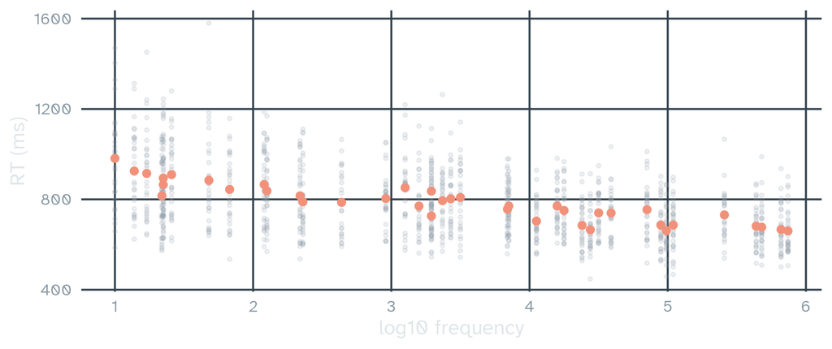

Grey: every response. Salmon: the mean RT for each word. Responses are noisy, but frequent words are faster on average.

## Log reaction times

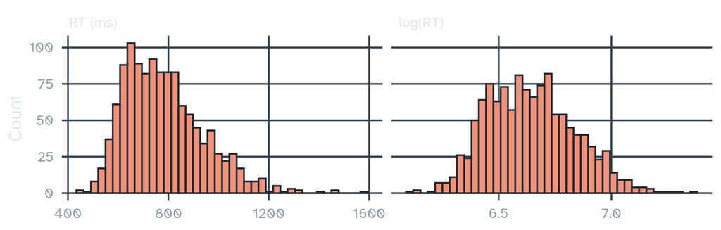

RTs are skewed to the right. In the simulation, every effect works on `log(rt)`, so all models in this lecture have `log(rt)` as the outcome, and a coefficient `b` multiplies RTs by `exp(b)`. For small values, `b = -0.05` means about 5% faster.

# The linear model

`Did you know:` in playback experiments, king penguin chicks picked out their parent’s call even when it was 6 dB quieter than the calls of other adults played at the same time.

*Source: Aubin & Jouventin (1998), Proceedings of the Royal Society B*

## The equation

y = b₀ + b₁ · x + e

- The intercept `b₀` is the predicted `y` when `x = 0`
- The slope `b₁` is how much `y` changes when `x` increases by one unit
- The residual `e` is the distance between each observation and the line

`lm()` finds the intercept and slope that minimise the sum of squared residuals: least squares.

## Intercept, slope and residuals

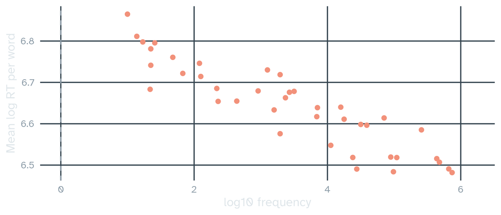

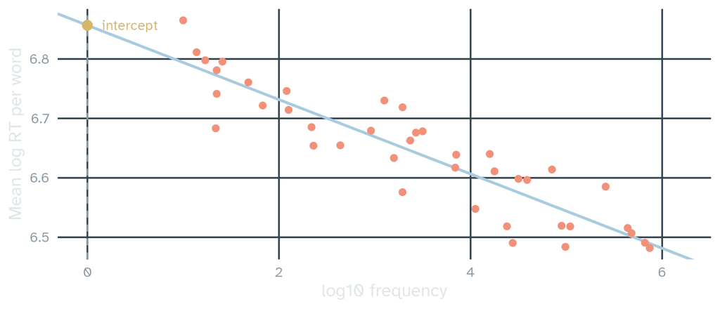

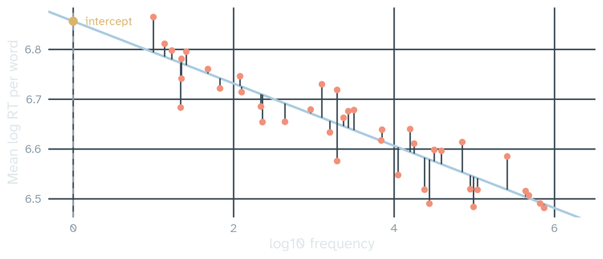

Word means, the regression line, and each word’s residual (vertical lines). The intercept sits at log frequency 0, far from the data.

## One predictor

```r
m1 <- lm(log(rt) ~ log_freq, data = lex)
coef(m1)
```

```
(Intercept)    log_freq
 6.85665674 -0.06252191
```

Each extra log unit of frequency multiplies RTs by 0.939: responses about 6.1% faster. The intercept is the predicted log RT for a word with log frequency 0, which none of our words has (`exp()` turns it into 950 ms).

## Centring

```r
lex <- lex |>
  mutate(freq_c = log_freq - mean(log_freq),
         length_c = length - mean(length))
coef(lm(log(rt) ~ freq_c, data = lex))
```

```
(Intercept)      freq_c
 6.64355081 -0.06252191
```

Centring moves 0 to the mean. The slope stays the same; the intercept becomes the predicted log RT for a word of average frequency (768 ms).

## The intercept after centring

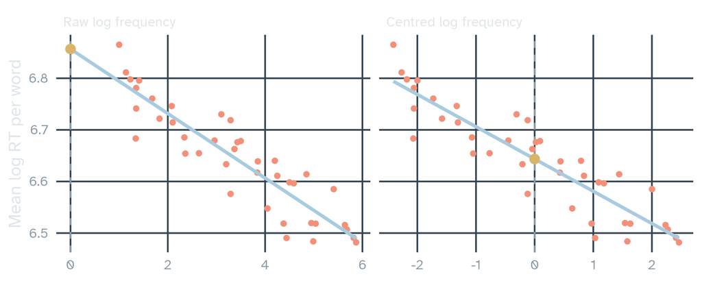

The line and its slope stay where they were. Centring moves 0, and with it the intercept (gold).

## `tidy()` and `glance()`

```r
tidy(lm(log(rt) ~ freq_c, data = lex))
```

```
# A tibble: 2 × 5
  term        estimate std.error statistic  p.value
  <chr>          <dbl>     <dbl>     <dbl>    <dbl>
1 (Intercept)   6.64     0.00494    1345.  0
2 freq_c       -0.0625   0.00335     -18.7 1.93e-68
```

```r
glance(lm(log(rt) ~ freq_c, data = lex))[, c("r.squared", "sigma", "nobs")]
```

```
# A tibble: 1 × 3
  r.squared sigma  nobs
      <dbl> <dbl> <int>
1     0.225 0.171  1200
```

R² is the share of the variance in log RT that the model accounts for. `sigma` is the residual standard deviation, on the log scale.

## Checking the residuals

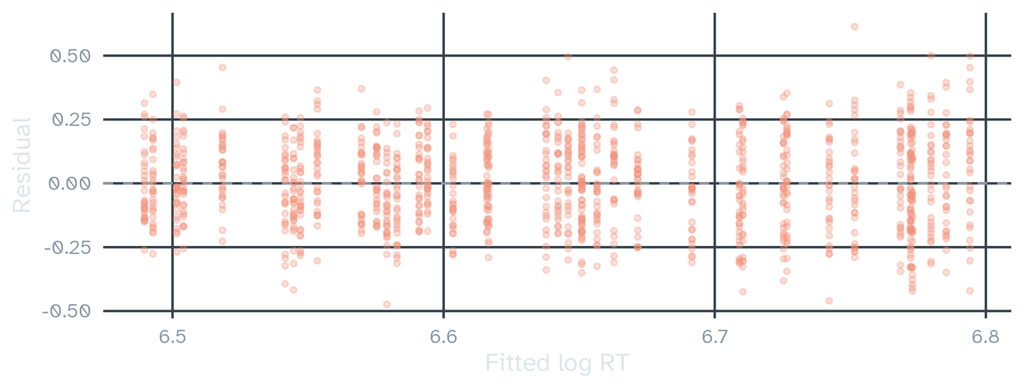

Linear models assume residuals that are roughly normal and equally spread along the fitted values. These residuals look fine on both counts.

# More predictors

`Did you know:` king penguin chicks need very little of a call to recognise a parent. The first half of one syllable (0.23 s), with only its three lowest harmonics, was enough.

*Source: Jouventin, Aubin & Lengagne (1999), Animal Behaviour*

## A categorical predictor

```r
coef(lm(log(rt) ~ group, data = lex))
```

```
(Intercept)     groupL2
  6.5395704   0.2079609
```

With treatment coding, R’s default, `group` becomes a 0/1 dummy. The intercept is the mean of the reference level (L1, the first level of the factor), and `groupL2` is the difference between L2 and L1.

## The intercept under each coding

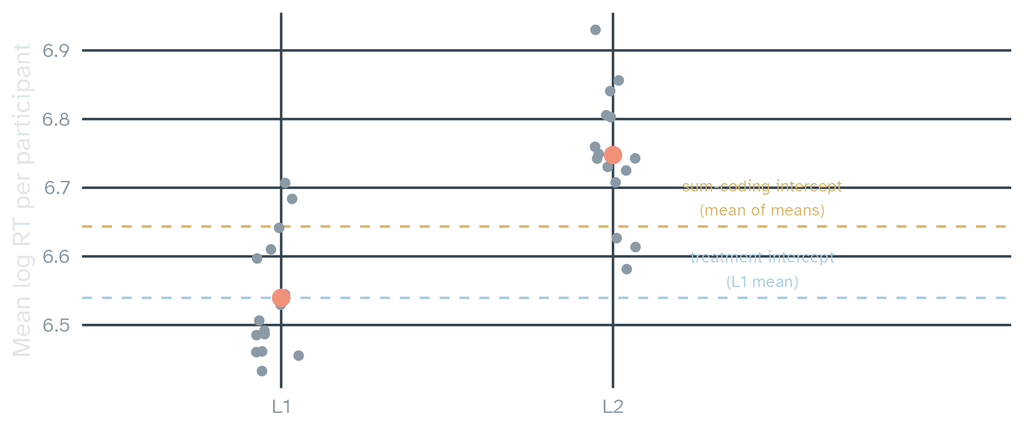

Grey: each participant’s mean. Salmon: the group means.

## Sum coding

```r
contrasts(lex$group) <- contr.sum(2)
coef(lm(log(rt) ~ group, data = lex))
```

```
(Intercept)      group1
  6.6435508  -0.1039804
```

With sum coding (−1 and 1 here, R’s `contr.sum()` gives L1 = 1), the intercept is the mean of the two group means, and `group1` is half the difference between them. This matters once we add interactions.

## Two continuous predictors

```r
m2 <- lm(log(rt) ~ freq_c + length_c, data = lex)
coef(m2)
```

```
(Intercept)      freq_c    length_c
 6.64355081 -0.04565557  0.01448920
```

Each slope is now the effect of one predictor holding the other constant. The frequency slope shrinks from -0.063 to -0.046: in the simple model, frequency also stood in for length, because frequent words are shorter.

## Simple and multiple slopes

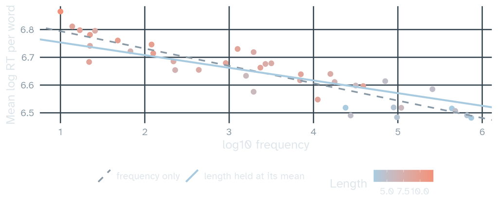

Frequent words are also short (blue), so the frequency-only line (dashed) mixes the two effects. Holding length constant gives the shallower slope.

## Correlated predictors

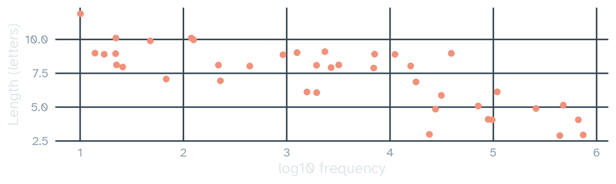

```r
words <- distinct(lex, word, log_freq, length)
cor(words$log_freq, words$length)
```

```
[1] -0.7715162
```

Frequent words tend to be short.

## Collinearity

- When predictors overlap, each coefficient rests on the part of the predictor the others do not share, so standard errors grow. This is collinearity
- Check it with a correlation matrix or variance inflation factors (`car::vif()`), and think about which predictors the design really needs

# Interactions

`Did you know:` king penguin chicks still recognised their parent’s call when its frequency was shifted 100 Hz down or 75 Hz up. Their recognition does not depend on exact pitch.

*Source: Jouventin, Aubin & Lengagne (1999), Animal Behaviour*

## A steeper slope for L2 speakers

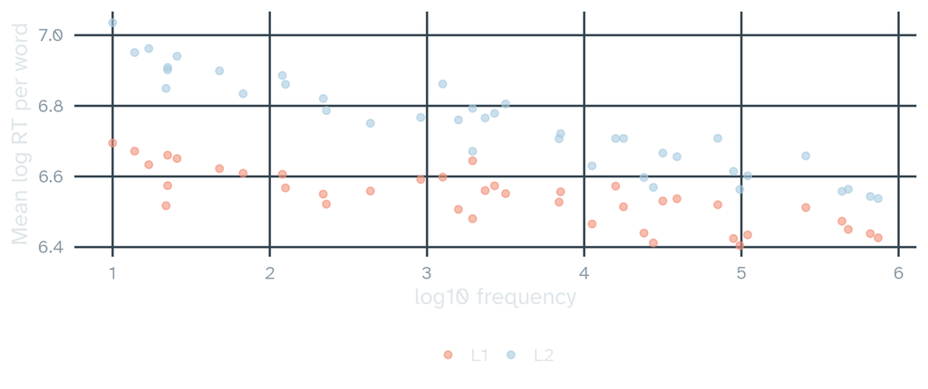

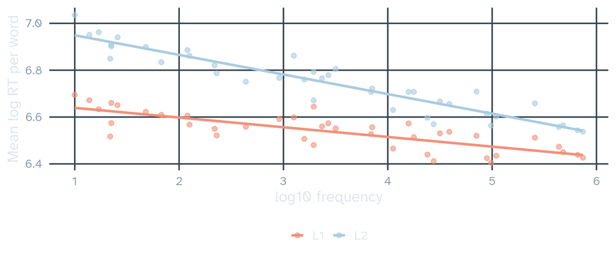

Frequency matters more for L2 speakers: the lines are not parallel.

## Fitting an interaction in R

```r
m3 <- lm(log(rt) ~ freq_c * group, data = lex)
coef(m3)
```

```
  (Intercept)        freq_c        group1 freq_c:group1
   6.64355081   -0.06252191   -0.10398044    0.02113053
```

`freq_c * group` is short for `freq_c + group + freq_c:group`. The interaction term `freq_c:group1` says how much the frequency slope changes between the groups.

## Reading the coefficients

With sum-coded `group` and centred `freq_c`:

- `(Intercept)` is the predicted log RT for an average-frequency word, averaged over the two groups
- `freq_c` is the frequency slope, averaged over the groups
- `group1` is half the L1–L2 difference at average frequency
- `freq_c:group1` is half the difference between the two slopes

With treatment coding and uncentred predictors, the same model is correct but `group` would be the L1–L2 difference at log frequency 0. Each lower-order term in an interaction model is a simple effect: the effect when the other predictor is 0.

## Reading interactions

- Plot the data and the fitted lines first
- Check how each predictor is coded and where its 0 is
- Read the interaction as a difference in slopes, or a difference in differences
- For three-way interactions, plot again before reading any number

# Mixed models

`Did you know:` king and emperor penguins call with two voices at once, one from each side of the syrinx. When one voice was removed from an emperor penguin’s call in playbacks, neither its mate nor its chick replied.

*Source: Aubin, Jouventin & Hildebrand (2000), Proceedings of the Royal Society B*

## Not independent

So far, `lm()` treated our 1200 rows as 1200 independent observations. They are not:

- each participant gave 40 responses, and some participants are faster than others
- each word was seen by 30 participants, and some words are easier than others

Ignoring this makes standard errors too small, so effects look more certain than they are.

## Participants differ

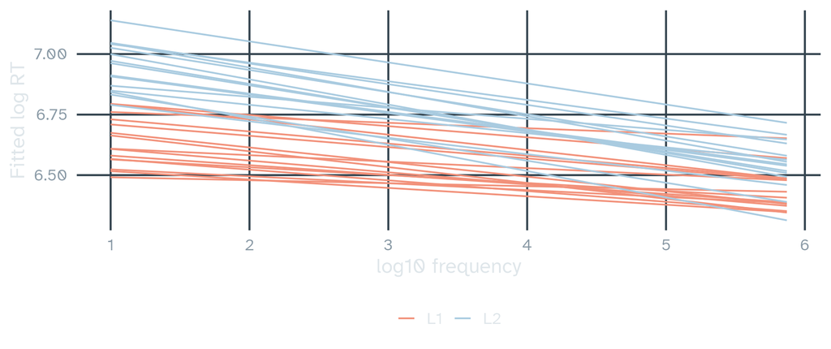

One line per participant: they differ in overall speed (intercepts) and in how much frequency helps them (slopes).

## Fixed and random effects

- Fixed effects are the predictors we want to estimate: frequency, length, group, their interaction
- Random effects model how grouping units vary around them: participants and words
- A random intercept lets each participant or word have its own baseline
- A random slope lets the effect of a predictor vary by participant (or word)

A random slope needs a predictor that varies within the grouping unit. Frequency and length vary within participants; group varies within words, because every word is seen by both groups.

## `lmer()` syntax

| Formula term | Meaning |
| --- | --- |
| `(1 \| participant)` | random intercepts by participant |
| `(1 + freq_c \| participant)` | random intercepts and frequency slopes, with their correlation |
| `(1 + freq_c \|\| participant)` | the same, without the correlation |
| `(1 \| word)` | random intercepts by word |

We fit `log(rt) ~ freq_c * group + length_c + (1 + freq_c | participant) + (1 | word)`. The maximal structure for this design would also include by-participant slopes for length and by-word slopes for group (Barr et al., 2013); we leave them out here to keep the example small.

## Fitting the model

```r
m4 <- lmer(log(rt) ~ freq_c * group + length_c +
             (1 + freq_c | participant) + (1 | word), data = lex)
round(fixef(m4), 3)
```

```
  (Intercept)        freq_c        group1      length_c freq_c:group1
        6.644        -0.046        -0.104         0.014         0.021
```

The fixed effects tell the same story as before: frequency speeds up responses, length slows them down, L2 speakers are slower, and the frequency slope differs between groups.

## Random effects

```r
VarCorr(m4)
```

```
 Groups      Name        Std.Dev. Corr
 word        (Intercept) 0.035348
 participant (Intercept) 0.089579
             freq_c      0.013191 -0.077
 Residual                0.089780
```

- Participants’ baselines vary with a standard deviation of about 0.09 on the log scale, roughly 9%; words’ baselines with about 0.035
- Participants’ frequency slopes vary around the fixed slope with a standard deviation of about 0.013
- `Residual` is the variation left over within participants and words

## Random intercepts of participants and words

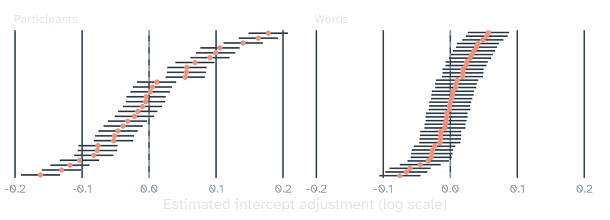

Each participant’s and each word’s random intercept, with a 95% interval. Participants spread more widely than words, as the standard deviations on the previous slide say.

## Standard errors

```r
m_lm <- lm(log(rt) ~ freq_c * group + length_c, data = lex)
rbind(lm = coef(summary(m_lm))["freq_c", 1:2],
      lmer = coef(summary(m4))["freq_c", 1:2])
```

```
        Estimate  Std. Error
lm   -0.04565557 0.004023610
lmer -0.04565557 0.006994933
```

The estimate barely changes, but its standard error grows once the model knows that responses from the same participant and word belong together.

## Wider intervals

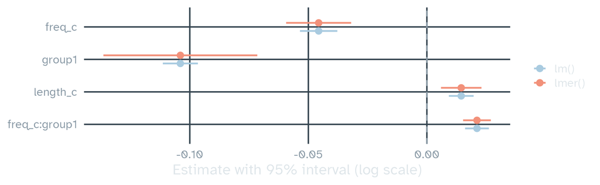

Estimate ± 1.96 SE for each fixed effect. The intervals widen most for `group1`, which varies between participants, so only 30 participants stand behind it.

## Partial pooling

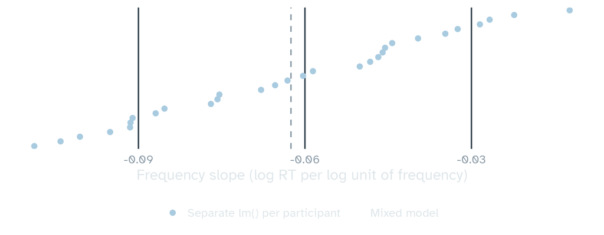

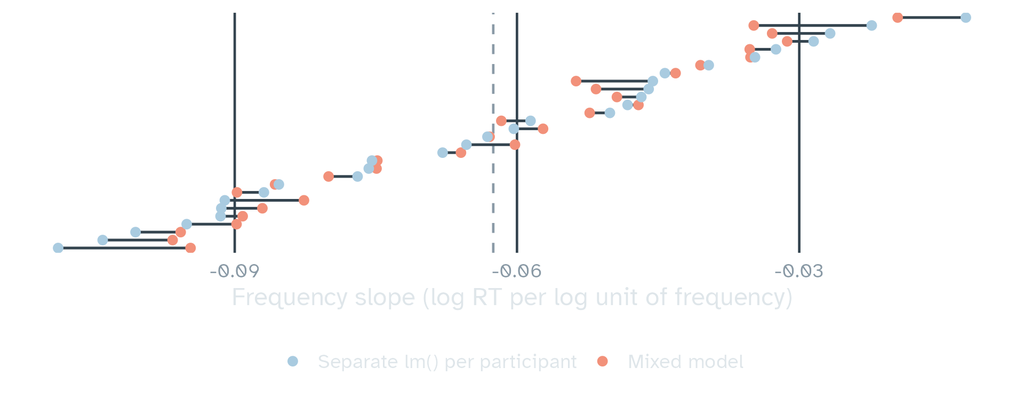

Each participant’s slope moves toward the overall slope (dashed). This shrinkage, also called partial pooling, lets extreme estimates borrow strength from the rest of the sample.

## Testing an effect

A likelihood ratio test compares two nested models fitted with maximum likelihood:

```r
m4_ml <- update(m4, REML = FALSE)
m4_noint <- update(m4_ml, . ~ . - freq_c:group)
anova(m4_noint, m4_ml)
```

```
Data: lex
Models:
m4_noint: log(rt) ~ freq_c + group + length_c + (1 + freq_c | participant) + (1 | word)
m4_ml: log(rt) ~ freq_c * group + length_c + (1 + freq_c | participant) + (1 | word)
         npar     AIC     BIC logLik -2*log(L) Chisq Df Pr(>Chisq)
m4_noint    9 -2126.6 -2080.8 1072.3   -2144.6
m4_ml      10 -2154.9 -2104.0 1087.5   -2174.9 30.32  1  3.664e-08

m4_noint
m4_ml    ***
---
Signif. codes:  0 '***' 0.001 '**' 0.01 '*' 0.05 '.' 0.1 ' ' 1
```

## p-values with `{lmerTest}`

```r
library(lmerTest)
m4 <- lmer(log(rt) ~ freq_c * group + length_c +
             (1 + freq_c | participant) + (1 | word), data = lex)
round(coef(summary(m4)), 3)
```

```
              Estimate Std. Error     df t value Pr(>|t|)
(Intercept)      6.644      0.017 34.245 380.137    0.000
freq_c          -0.046      0.007 45.082  -6.527    0.000
group1          -0.104      0.017 28.000  -6.279    0.000
length_c         0.014      0.004 37.000   3.329    0.002
freq_c:group1    0.021      0.003 27.999   7.087    0.000
```

`{lmerTest}` adds degrees of freedom (Satterthwaite’s approximation) and p-values to the fixed effects.

## When things go wrong

- A convergence warning means the optimiser may not have found the best estimates. Check the data and scaling, try another optimiser (`lmerControl(optimizer = "bobyqa")`), and simplify only if needed
- A singular fit means some variance or correlation is estimated at its boundary, often a random-effect correlation of ±1 or a standard deviation of 0. The data cannot support that part of the structure

In both cases, simplify step by step and report what you removed: first correlations, then the random slopes that explain least.

## Reporting

A sentence for our model:

> We fitted a linear mixed model to log-transformed RTs with centred log frequency, sum-coded group, their interaction and centred length as fixed effects, by-participant random intercepts and frequency slopes, and by-word random intercepts (`lme4`; Bates et al., 2015). The frequency effect was stronger for L2 than for L1 speakers (interaction, with L1 coded 1 and L2 −1: b = 0.021, SE = 0.003, p < .001).

Report the full model structure, the coding of each predictor, and how the model was simplified, if it was.

## Summary

- A linear model estimates an intercept and slopes; centring makes the intercept meaningful
- Treatment and sum coding answer different questions about categorical predictors
- With several predictors, each slope holds the others constant; collinearity makes slopes uncertain
- In an interaction model, each lower-order term is a simple effect, so coding and centring decide what it means
- Mixed models add random intercepts and slopes for participants and items, which gives honest standard errors and shrinks individual estimates toward the group

## References

- Barr, D. J., Levy, R., Scheepers, C., & Tily, H. J. (2013). Random effects structure for confirmatory hypothesis testing: Keep it maximal. *Journal of Memory and Language*, 68(3), 255–278. https://doi.org/10.1016/j.jml.2012.11.001
- Bates, D., Mächler, M., Bolker, B., & Walker, S. (2015). Fitting linear mixed-effects models using lme4. *Journal of Statistical Software*, 67(1), 1–48. https://doi.org/10.18637/jss.v067.i01
- Kuznetsova, A., Brockhoff, P. B., & Christensen, R. H. B. (2017). lmerTest package: Tests in linear mixed effects models. *Journal of Statistical Software*, 82(13), 1–26. https://doi.org/10.18637/jss.v082.i13
- Winter, B. (2019). *Statistics for Linguists: An Introduction Using R*. Routledge. Chapters 4–8, 14 and 15. https://doi.org/10.4324/9781315165547

## Sources of the animal facts

- Aubin, T., & Jouventin, P. (1998). Cocktail-party effect in king penguin colonies. *Proceedings of the Royal Society B*, 265(1406), 1665–1673. https://doi.org/10.1098/rspb.1998.0486
- Aubin, T., Jouventin, P., & Hildebrand, C. (2000). Penguins use the two-voice system to recognize each other. *Proceedings of the Royal Society B*, 267(1448), 1081–1087. https://doi.org/10.1098/rspb.2000.1112
- Howlett, R. (1998). Pick out a penguin. *Nature*, 395, 637. https://doi.org/10.1038/27075
- Jouventin, P., Aubin, T., & Lengagne, T. (1999). Finding a parent in a king penguin colony: The acoustic system of individual recognition. *Animal Behaviour*, 57(6), 1175–1183. https://doi.org/10.1006/anbe.1999.1086

## Slides and code

[figure not shown]

These slides

mcanzi.de/advanced_statistics/01_refresher.html

Code and all lectures

github.com/mcanzi/advanced_statistics